# 07 Time Series Models

Eduardo Villarreal

13/8/2021

```r
require(tidyverse)
require(data.table)
require(gridExtra) #Libreria para hacer paneles de gráficas con ggplot2
require(forecast) #Libreria para análisis de series de tiempo
require(fpp2) #Datos de eries de tiempo
require(timetk) #To work with time series
require(modeltime) #To model time series models
require(tidyquant) #Timeserioes Operarions
require(hts) #Library for multiple time series data
require(zoo)
```

En esta ocasión vamos a utilizar datos de `CoVid19` para predecir la tendencia de nuevos casos de la serie diaria. La fuente de información es `Our World in Data`

```r
#Descargar los datos de CoVid
covid_wdb = fread('https://covid.ourworldindata.org/data/owid-covid-data.csv')

#crear el campo de Fecha
covid_wdb$Date = as.Date(covid_wdb$date, format = '%Y-%m-%d')
head(covid_wdb)
```

| iso_code | continent | location | date | total_cases | new_cases | new_cases_smoothed | total_deaths | new_deaths | new_deaths_smoothed | total_cases_per_million | new_cases_per_million | new_cases_smoothed_per_million | total_deaths_per_million | new_deaths_per_million | new_deaths_smoothed_per_million | reproduction_rate | icu_patients | icu_patients_per_million | hosp_patients | hosp_patients_per_million | weekly_icu_admissions | weekly_icu_admissions_per_million | weekly_hosp_admissions | weekly_hosp_admissions_per_million | new_tests | total_tests | total_tests_per_thousand | new_tests_per_thousand | new_tests_smoothed | … |
| --- | --- | --- | --- | --- | --- | --- | --- | --- | --- | --- | --- | --- | --- | --- | --- | --- | --- | --- | --- | --- | --- | --- | --- | --- | --- | --- | --- | --- | --- | --- |
| AFG | Asia | Afghanistan | 2020-02-24 | 1 | 1 | NA | NA | NA | NA | 0.026 | 0.026 | NA | NA | NA | NA | NA | NA | NA | NA | NA | NA | NA | NA | NA | NA | NA | NA | NA | NA | … |
| AFG | Asia | Afghanistan | 2020-02-25 | 1 | 0 | NA | NA | NA | NA | 0.026 | 0.000 | NA | NA | NA | NA | NA | NA | NA | NA | NA | NA | NA | NA | NA | NA | NA | NA | NA | NA | … |
| AFG | Asia | Afghanistan | 2020-02-26 | 1 | 0 | NA | NA | NA | NA | 0.026 | 0.000 | NA | NA | NA | NA | NA | NA | NA | NA | NA | NA | NA | NA | NA | NA | NA | NA | NA | NA | … |
| AFG | Asia | Afghanistan | 2020-02-27 | 1 | 0 | NA | NA | NA | NA | 0.026 | 0.000 | NA | NA | NA | NA | NA | NA | NA | NA | NA | NA | NA | NA | NA | NA | NA | NA | NA | NA | … |
| AFG | Asia | Afghanistan | 2020-02-28 | 1 | 0 | NA | NA | NA | NA | 0.026 | 0.000 | NA | NA | NA | NA | NA | NA | NA | NA | NA | NA | NA | NA | NA | NA | NA | NA | NA | NA | … |
| AFG | Asia | Afghanistan | 2020-02-29 | 1 | 0 | 0.143 | NA | NA | 0 | 0.026 | 0.000 | 0.004 | NA | NA | 0 | NA | NA | NA | NA | NA | NA | NA | NA | NA | NA | NA | NA | NA | NA | … |

# 1 Análisis descriptivo de la serie

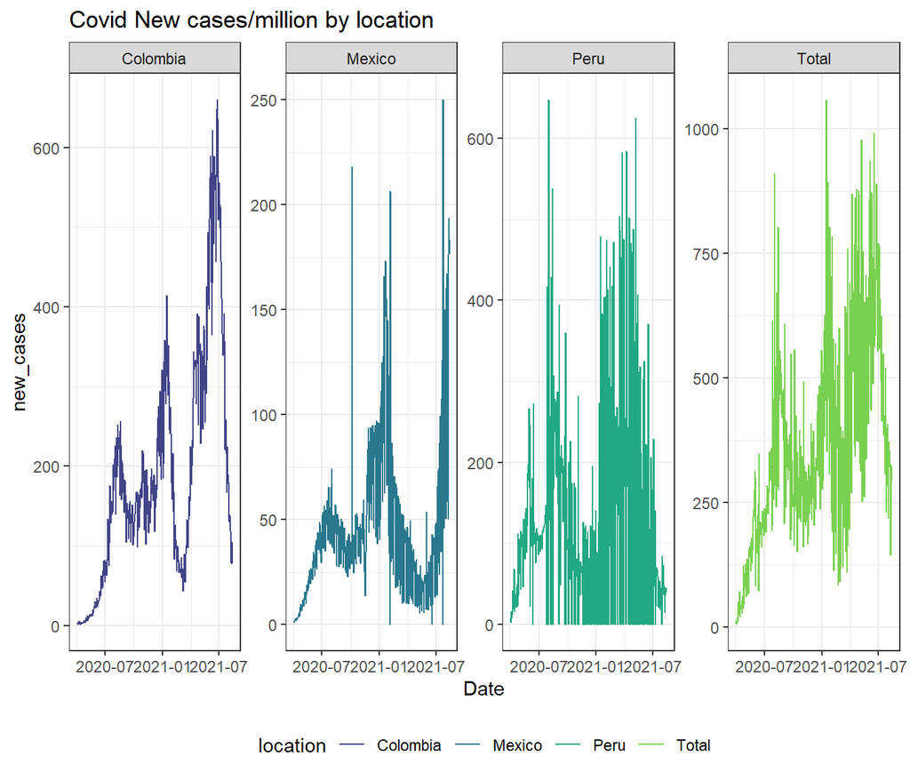

```r
pais = c('Mexico', 'Colombia', 'Peru', 'Brasil')
pais_MA = paste(pais, 'MA14', sep = '_')

#Querie para filtrar solo los paises de interés
MA_covid = covid_wdb %>%
  filter(location %in% pais) %>%
  mutate(new_cases = new_cases_per_million) %>%
  dplyr::select(Date, location, new_cases) %>%
  spread(location, new_cases, fill = 0)

#Crear Total y solo tomar desde Abril del 2020
MA_covid$Total = rowSums(MA_covid[, 2 : ncol(MA_covid)])
MA_covid = MA_covid %>%
  filter(Date >= '2020-04-01') %>%
  gather(location, new_cases, 2 : ncol(.))

#Grafica de los casos diarios
MA_covid %>%
  ggplot(aes(x = Date, y = new_cases, color = location)) +
  geom_line() +
  facet_wrap(~location, scales = 'free', nrow = 1) +
  theme_bw() +
  scale_color_viridis_d(begin = 0.2, end = 0.8) +
  labs(title = 'Covid New cases/million by location') +
  theme(legend.position = 'bottom')
```

## 1.1 Seasonal Decomposition

Como vimos en la introducción, una serie de tiempos es la combinación de 3 elementos:

Nivel

Tendencia

Estacionalidad

$y_t = N_t + T_t + S_t +\epsilon_t$

Ajuste por Estacionalidad

Si removemos el componente estacional de los datos el resultado es una serie desestacionalida:

$y_t - S_t = N_t + T_t + \epsilon_t$ si la series es aditiva y si la series es múltiplicativa, obtenemos:

$\frac{y_t}{S_t} = N_t \times T_t \times \epsilon_t$

Desestacionalizar una serie es útil cuando la variación estacional de la serie no es de interés. Por ejemplo, la tasa mensual de desempleo suele analizarse sin estacionalidad. Por ejemplo, una caída en la tasa de desempleo debido a los trabajos escolares.

Siguiendo con la serie de Covid Total, para ajustar por estacionalidad primero aplicamos la función `decompose` y posteriormente aplicamos la función `seasadj`:

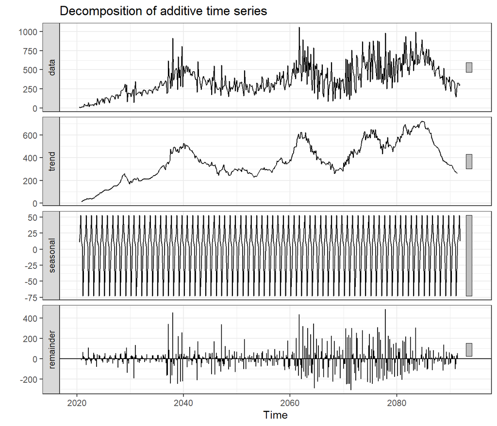

```r
MA_covid = MA_covid %>%
  spread(location, new_cases, fill = 0)

covid_total = ts(MA_covid$Total, frequency = 7, start = c(2020, 4))

covid_dcomposed = decompose(covid_total)
autoplot(covid_dcomposed) +
  theme_bw()
```

El objeto `covid_decomsed` tiene los componentes de **Tendencia**, **Etacionalidad** y el componente **Aleatorio**. Por ejemplo, para mejorar la visualización de la gráfica, podemos eliminar el ciclo estacional haciendo:

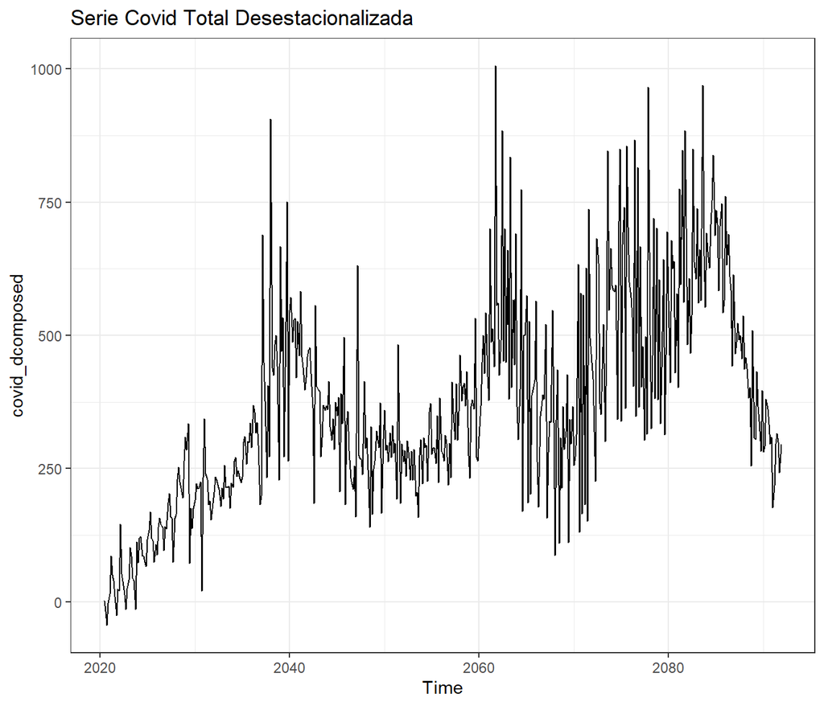

```r
covid_dcomposed = seasadj(covid_dcomposed)
autoplot(covid_dcomposed) +
  theme_bw() +
  labs(title = 'Serie Covid Total Desestacionalizada')
```

En este caso estamos observando la serie $z_t = y_t - S_t$; es decir, el componente de tendencia y error aleatorio.

Si quisiéramos observar la tendencia de la serie, podemos extraer la tendencia como:

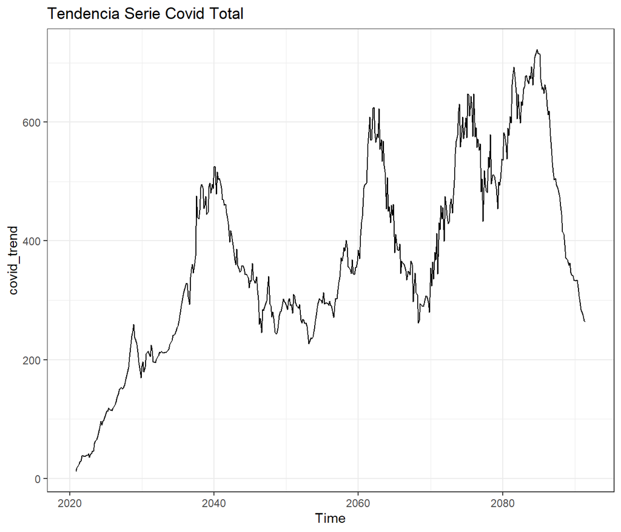

```r
covid_dcomposed = decompose(covid_total)
covid_trend = covid_dcomposed$trend
autoplot(covid_trend) +
  theme_bw() +
  labs(title = 'Tendencia Serie Covid Total')
```

## 1.2 Moving Average Smoothing

Otra forma de visualizar la serie es utilizando **Moving Averages**.

Este tipo de computos se refiere a ventanas de tiempo bajo las cuales se calcula algún tipo de estadístico como la media la desviación estándar o la correlación entre dos series de tiempo. Un ejemplo es el cómputo de Media Móvil o MA(L):

$MA(L) = \frac{1}{L}\sum_{t=1}^L X_t$

```r
MA_smooth = MA_covid %>%
  select(Date, Total) %>%
  tq_mutate(
    select = Total,
    mutate_fun = rollapply,
    width = 20,
    FUN = mean,
    col_rename = 'MA20') %>%
  tq_mutate(
    select = Total,
    mutate_fun = rollapply,
    width = 50,
    FUN = mean,
    col_rename = 'MA50')
```

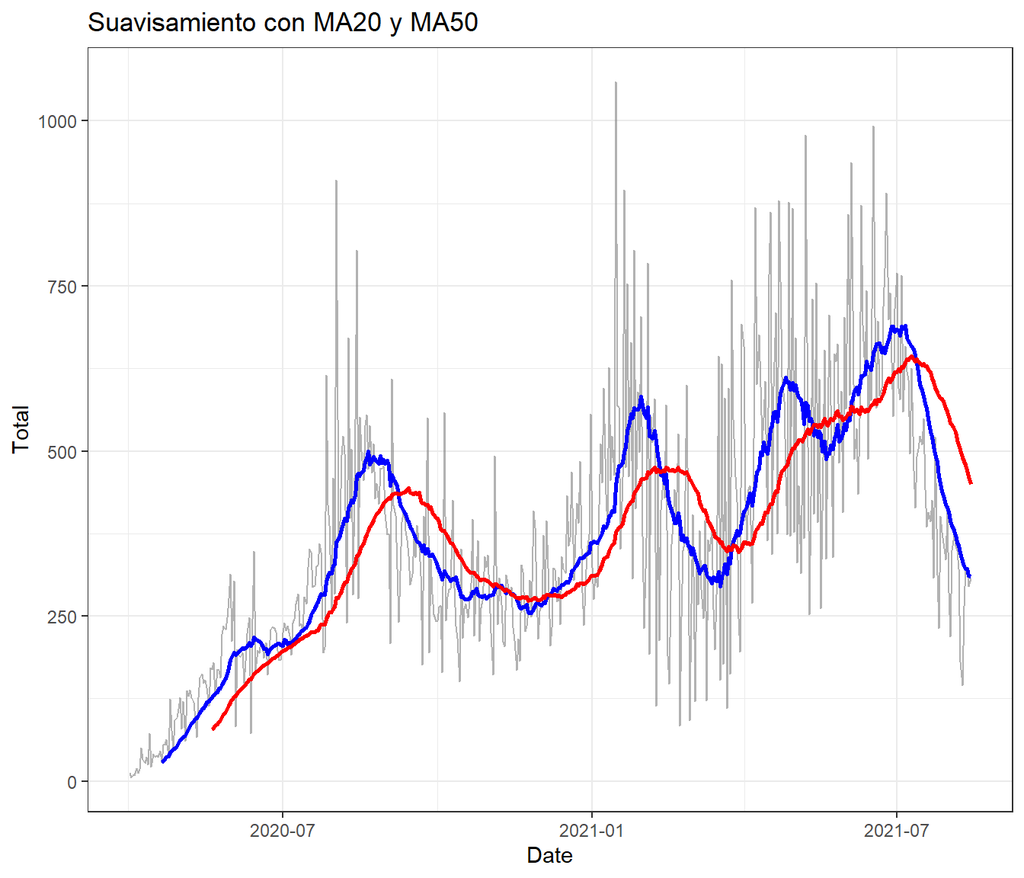

```r
#Graficar
MA_smooth %>%
  ggplot(aes(x = Date, y = Total)) +
  geom_line(alpha = 0.6, col = 'grey50') +
  geom_line(aes(y = MA20), size = 1, col = 'blue') +
  geom_line(aes(y = MA50), size = 1, col = 'red') +
  theme_bw() +
  labs(title = 'Suavisamiento con MA20 y MA50')
```

En este caso, estamos usando un `MA(20)` como una medida de la tendencia a **corto plazo** y un `MA(50)` como una medida de **largo plazo**. Lo interesante de estos patrones son los **cruces** entre las dos líneas:

## 1.3 Caso particular de México

Ahora vamos a hacer el caso particular de México

```r
MA_smooth = MA_covid %>%
  select(Date, Mexico) %>%
  tq_mutate(
    select = Mexico,
    mutate_fun = rollapply,
    width = 21,
    FUN = mean,
    col_rename = 'MA_short') %>%
  tq_mutate(
    select = Mexico,
    mutate_fun = rollapply,
    width = 21 * 3,
    FUN = mean,
    col_rename = 'MA_long')
```

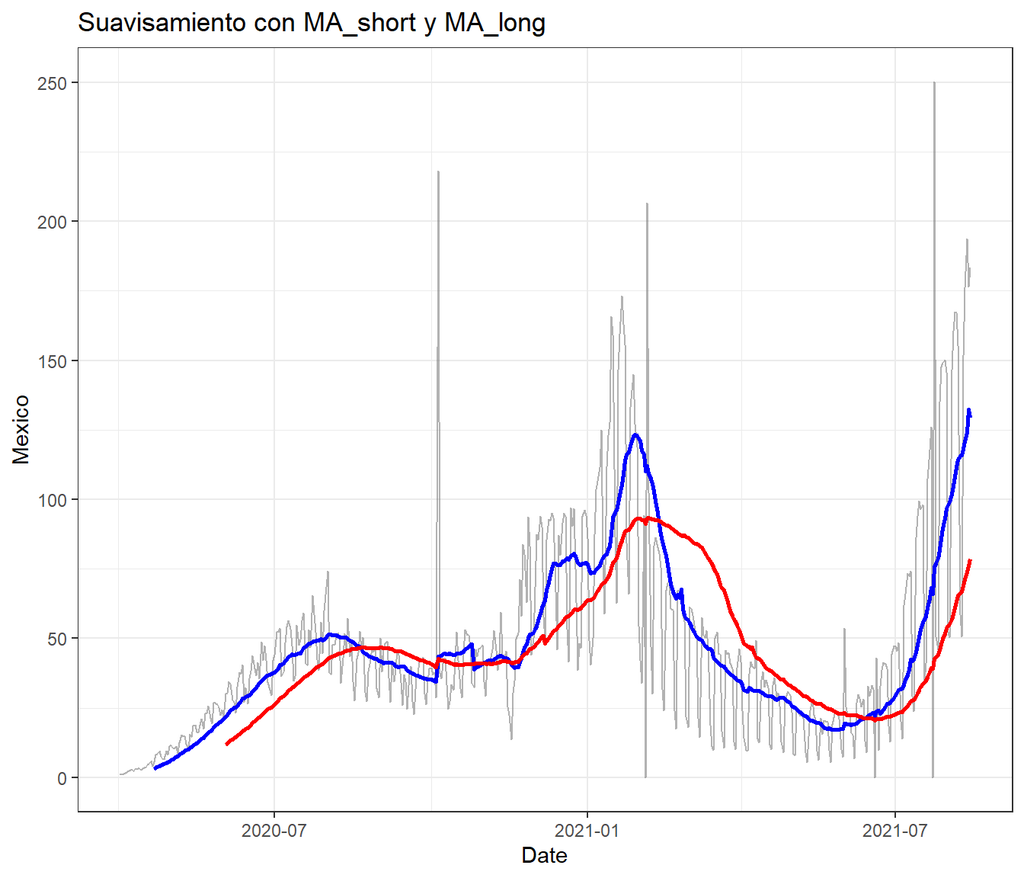

```r
#Graficar
MA_smooth %>%
  ggplot(aes(x = Date, y = Mexico)) +
  geom_line(alpha = 0.6, col = 'grey50') +
  geom_line(aes(y = MA_short), size = 1, col = 'blue') +
  geom_line(aes(y = MA_long), size = 1, col = 'red') +
  theme_bw() +
  labs(title = 'Suavisamiento con MA_short y MA_long')
```

**Qué podemos observar del comportamiento en la 3ra ola?**

## 1.4 STL Decomposition

**STL** es un acrónimo de **Seasonal and Trend decomposition using LOESS** en dondo **LOESS** es un método para estimar relaciones no lineales que usa **regression splins** para ajustarse en forma adaptativa.

**STL** tiene muchas ventajas:

1. Puede manejar cualquier tipo de estacionalidad: diaria, semanal, anual, etc.
2. El componente estacional es adaptativo en el tiempo
3. Es robusto ante la presencia de outliers

Hay dos parámetros que debe poner el usiario: `t.window` (trend-cycle window) y `s.window` (seasonal window). Estos dos parámetros controlan qué tan rápido pueden adaptarse ambos componentes. Valores pequeños permiten cambios más rápidos. Ambos valores deben ser **impares**.

Una interpretación más precisa de ambos parámetros es `t.window`es el número de observaciones consecutivas utilizadas para estimar el componente de ciclo-tendencia.

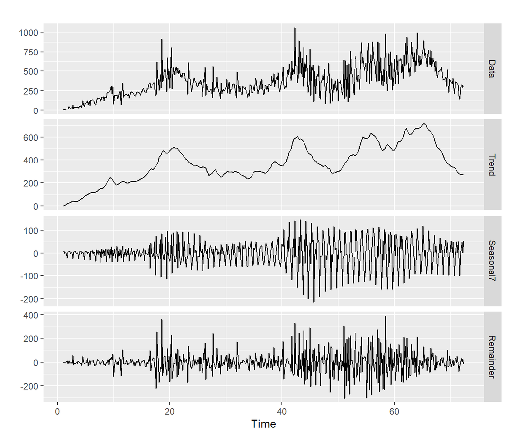

```r
MA_covid$Total %>%
  ts(frequency = 7) %>%
  mstl() %>%
  autoplot()
```

Observe cómo, a diferencia de `decompose`, el componente estacional varia a lo largo del tiempo.

Si quisieramos ajustar los datos eliminando la estacionalidad, podemos hacer $z_t = y_t - S_t$:

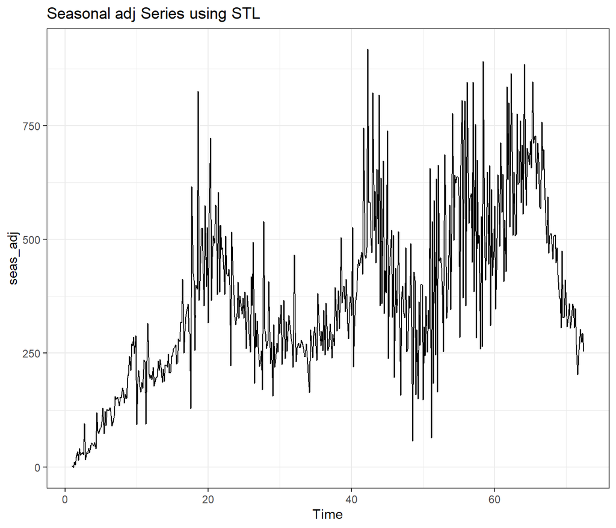

```r
seasonal_eff = MA_covid$Total %>%
  ts(frequency = 7) %>%
  mstl()

#Seasonal djusted series
seas_adj = MA_covid$Total - seasonal_eff[, 3]
autoplot(seas_adj) +
  theme_bw() +
  labs(title = 'Seasonal adj Series using STL')
```

Y si quisieramos observar la tendencia, podemos hacer:

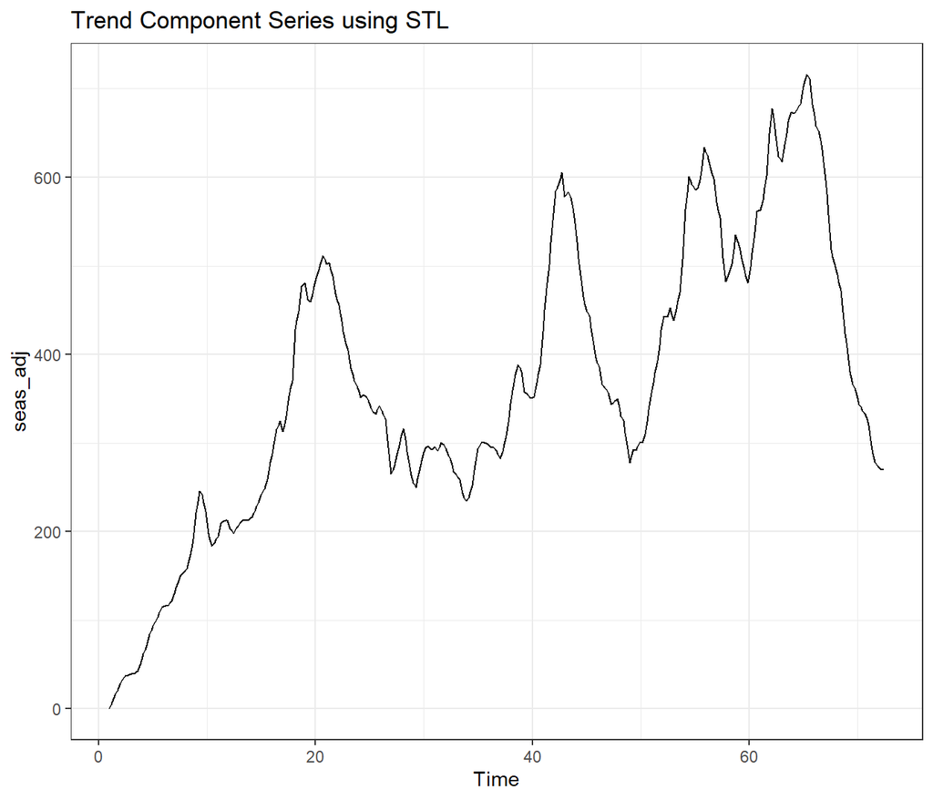

```r
seas_adj = MA_covid$Total - seasonal_eff[, 3] - seasonal_eff[, 4]
autoplot(seas_adj) +
  theme_bw() +
  labs(title = 'Trend Component Series using STL')
```

### 1.4.1 Qué tan fuerte es la Tendencia y la Estacionalidad?

Para datos con una tendencia muy fuerte los datos ajustados por estacionalidad deben tener mucha más varianza que el componente aleatorio. Así, el ratio $\text{Var}(\epsilon_t) / \text{Var}(T_t + \epsilon_t)$ debería ser relativamente pequeño. Para datos con poca o nula tendencia ambas variazas deberian ser aproximadamente iguales. Entonces definimos la fuerza de la tendencia $F_t$ como:

$F_T = max(0, 1 - \frac{\text{Var}(\epsilon_t)}{\text{Var}(T_t + \epsilon_t)})$

De manera similar podemos definir la fortaleza del factor estacional como:

$F_S = max(0, 1 - \frac{\text{Var}(\epsilon_t)}{\text{Var}(S_t + \epsilon_t)})$

```r
#Funcion para definir la fortaleza de la Tendencia y la Estacionalidad

FT_strenght = function(data, freq = 12){
  x = data
  x = ts(x, frequency = freq)

  #Time Series decomposition using STL
  x_decompose = mstl(x)
  trend_t = x_decompose[, 2]
  season_t = x_decompose[, 3]
  reminder_t = x_decompose[, 4]

  #Strength of a Trend
  F_Trend = var(reminder_t) / var(trend_t + reminder_t)
  F_Trend = max(0, 1 - F_Trend)

  return(F_Trend)
}


FS_strenght = function(data, freq = 12){
  x = data
  x = ts(x, frequency = freq)

  #Time Series decomposition using STL
  x_decompose = mstl(x)
  trend_t = x_decompose[, 2]
  season_t = x_decompose[, 3]
  reminder_t = x_decompose[, 4]

  #Strength of a Seasonal


  F_Season = var(reminder_t) / var(season_t + reminder_t)
  F_Season = max(0, 1 - F_Season)

  return(F_Season)
}

#Caso particular de Covid total
FS_strenght(MA_covid$Total, freq = 7)
```

```
## [1] 0.317292
```

```r
FT_strenght(MA_covid$Total, freq = 7)
```

```
## [1] 0.7583633
```

```r
#Caso de todas las series
sapply(MA_covid[, 2 : ncol(MA_covid)], FS_strenght)
```

```
##   Colombia     Mexico       Peru      Total
## 0.11295914 0.09925648 0.19013136 0.16987691
```

```r
sapply(MA_covid[, 2 : ncol(MA_covid)], FT_strenght)
```

```
##  Colombia    Mexico      Peru     Total
## 0.9668527 0.7042746 0.3613823 0.7129427
```

Esto es muy útil cuando queremos detectar en un conjunto de series de tiempo quiénes tienen Tendecia y Estacionalidad fuerte.

## 1.5 Descomposición Estacional con Series de Fourier

Una serie de Fourier es una serie infinita que converge puntualmente a una función periódica y continua a trozos (o por partes). Las series de Fourier constituyen la herramienta matemática básica del análisis de Fourier empleado para analizar funciones periódicas a través de la descomposición de dicha función en una suma infinita de funciones sinusoidales mucho más simples (como combinación de senos y cosenos con frecuencias enteras).

El nombre se debe al matemático francés Jean-Baptiste Joseph Fourier, que desarrolló la teoría cuando estudiaba la ecuación del calor. Fue el primero que estudió tales series sistemáticamente, y publicó sus resultados iniciales en 1807 y 1811. Esta área de investigación se llama algunas veces análisis armónico.

Las series de Fourier tienen la forma:

$y_t = \sum_{k=1}^K \left[\gamma_k \sin\left(\textstyle\frac{2\pi t k}{m}\right) \psi_k\cos\left(\textstyle\frac{2\pi t k}{m}\right)\right]$

En donde $1 < K < m/2$. Mientras más grande es el valor de $K$ el componente estacional es más complejo. El valor óptimo de $K$ puede estimase minimizando algún criterio como **AIC** o **leave-one-out CV**

La función `fourier()` puede usarse para estimar la serie de fourier:

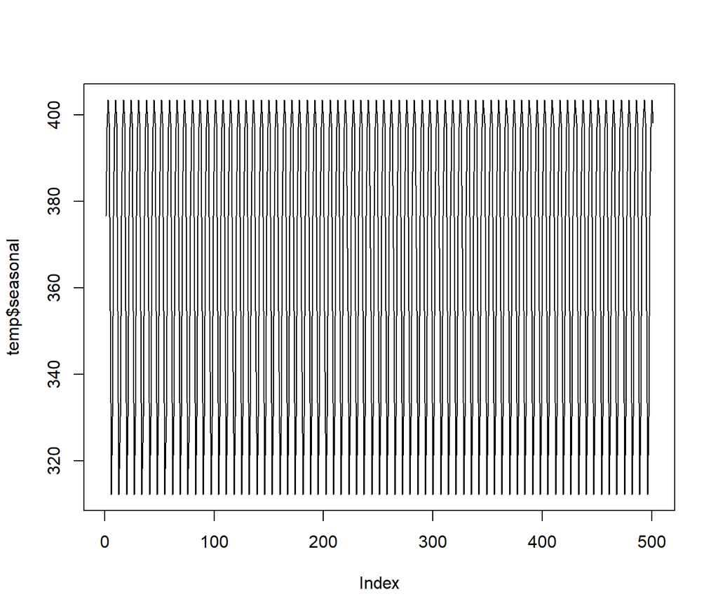

```r
#Estimación de la serie de fourier
Fourier = MA_covid$Total %>%
  ts(frequency = 7) %>%
  fourier(K = 2) %>%
  as.data.frame()

#Estimacion de los coeficientes de Fourier usando regresión lineal
temp = Fourier
temp$y = MA_covid$Total
seasonal_model = lm(y ~., data = temp)

#Seasonal component
temp$seasonal = seasonal_model$fitted.values

#graficar el componente esacional
plot(temp$seasonal, type = 'l')
```

### 1.5.1 Descomposición con Regresión Lineal y Series de Fourier

Podemos ahora descomponer la serie como:

$y_t = \alpha + \beta t + \sum_{k=1}^K \left[\gamma_k \sin\left(\textstyle\frac{2\pi t k}{m}\right) \psi_k\cos\left(\textstyle\frac{2\pi t k}{m}\right)\right] + \varepsilon_t$

```r
#Estimat con Regresión lineal

temp = MA_covid %>%
  select(Date, Total) %>%
  mutate(Trend = 1 : nrow(.))

#Estimacion de Series de Fourier
Fourier = MA_covid$Total %>%
  ts(frequency = 7) %>%
  fourier(K = 2) %>%
  as.data.frame()

#Aumentar el data frame
temp = bind_cols(temp, Fourier)
head(temp)
```

|  | Date | Total | Trend | S1-7 | C1-7 | S2-7 | C2-7 |
| --- | --- | --- | --- | --- | --- | --- | --- |
| 1 | 2020-04-01 | 12.214 | 1 | 0.7818315 | 0.6234898 | 0.9749279 | -0.2225209 |
| 2 | 2020-04-02 | 5.671 | 2 | 0.9749279 | -0.2225209 | -0.4338837 | -0.9009689 |
| 3 | 2020-04-03 | 8.954 | 3 | 0.4338837 | -0.9009689 | -0.7818315 | 0.6234898 |
| 4 | 2020-04-04 | 8.879 | 4 | -0.4338837 | -0.9009689 | 0.7818315 | 0.6234898 |
| 5 | 2020-04-05 | 19.741 | 5 | -0.9749279 | -0.2225209 | 0.4338837 | -0.9009689 |
| 6 | 2020-04-06 | 12.635 | 6 | -0.7818315 | 0.6234898 | -0.9749279 | -0.2225209 |

```r
#Modelo de Regresión
model_decompose = lm(Total ~., data = temp[, -1])
summary(model_decompose)
```

```
##
## Call:
## lm(formula = Total ~ ., data = temp[, -1])
##
## Residuals:
##     Min      1Q  Median      3Q     Max
## -377.20  -98.06  -22.55   87.86  661.25
##
## Coefficients:
##              Estimate Std. Error t value Pr(>|t|)
## (Intercept) 158.58633   14.03547  11.299  < 2e-16 ***
## Trend         0.83224    0.04845  17.177  < 2e-16 ***
## `S1-7`       27.14352    9.91098   2.739 0.006390 **
## `C1-7`      -36.75393    9.90853  -3.709 0.000231 ***
## `S2-7`       11.71054    9.90246   1.183 0.237540
## `C2-7`       -1.09958    9.91701  -0.111 0.911758
## ---
## Signif. codes:  0 '***' 0.001 '**' 0.01 '*' 0.05 '.' 0.1 ' ' 1
##
## Residual standard error: 156.8 on 495 degrees of freedom
## Multiple R-squared:  0.3909, Adjusted R-squared:  0.3848
## F-statistic: 63.54 on 5 and 495 DF,  p-value: < 2.2e-16
```

Ahora podemos descomponer la serie:

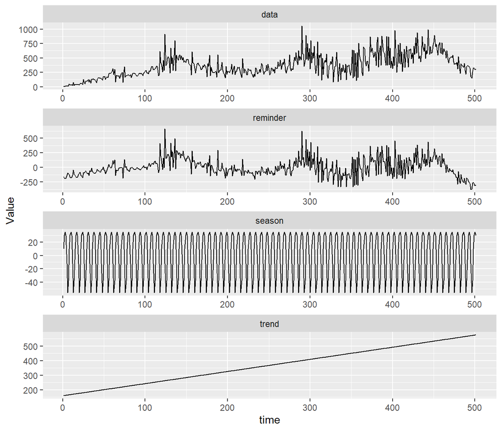

```r
trend = coef(model_decompose)[1] + coef(model_decompose)['Trend'] * temp$Trend
season = temp$Total - trend - residuals(model_decompose)


components = cbind(
  time = temp$Trend,
  data = temp$Total,
  trend = trend,
  season = season,
  reminder = residuals(model_decompose))

#graficar
components %>%
  as.data.frame() %>%
  gather(Series, Value, 2 : ncol(.)) %>%
  ggplot(aes(x = time, y = Value)) +
  geom_line() +
  facet_wrap(~Series, scales = 'free', ncol = 1)
```

Podemos tambien mejorar la tendencia utilizando **splines**

Podemos particionar el tiempo (la tendencia) en 3 momentos diferentes, definidos arbitrariamente como $Q_1, Q_2, Q_3$ que representan el quartil 1, 2 y 3 respectivamente:

```r
summary(temp$Trend)
```

```
##    Min. 1st Qu.  Median    Mean 3rd Qu.    Max.
##       1     126     251     251     376     501
```

Nuestra partición quearía como `c(126, 251, 376)` y usamos el concepto de **Cubic Splin** para ajustar la tendencia:

```r
temp = MA_covid %>%
  select(Date, Total) %>%
  mutate(Trend = 1 : nrow(.))

#compute Fourier Series
Fourier = MA_covid$Total %>%
  ts(frequency = 7) %>%
  fourier(K = 2) %>%
  as.data.frame()
temp = bind_cols(temp, Fourier)

require(splines)
#compute Trend using basis functions
m2 = lm(Total ~ bs(Trend, knots = c(126, 251,376)) - 1, data = temp)
Trend = m2$fitted.values
summary(m2)
```

```
##
## Call:
## lm(formula = Total ~ bs(Trend, knots = c(126, 251, 376)) - 1,
##     data = temp)
##
## Residuals:
##     Min      1Q  Median      3Q     Max
## -350.01  -73.02   -9.42   61.62  708.51
##
## Coefficients:
##                                      Estimate Std. Error t value Pr(>|t|)
## bs(Trend, knots = c(126, 251, 376))1   120.24      35.56   3.382 0.000778 ***
## bs(Trend, knots = c(126, 251, 376))2   471.08      39.12  12.043  < 2e-16 ***
## bs(Trend, knots = c(126, 251, 376))3   265.65      34.42   7.718 6.58e-14 ***
## bs(Trend, knots = c(126, 251, 376))4   462.60      41.15  11.241  < 2e-16 ***
## bs(Trend, knots = c(126, 251, 376))5   787.04      42.88  18.356  < 2e-16 ***
## bs(Trend, knots = c(126, 251, 376))6   212.06      39.18   5.412 9.72e-08 ***
## ---
## Signif. codes:  0 '***' 0.001 '**' 0.01 '*' 0.05 '.' 0.1 ' ' 1
##
## Residual standard error: 138.1 on 495 degrees of freedom
## Multiple R-squared:  0.8924, Adjusted R-squared:  0.8911
## F-statistic: 684.3 on 6 and 495 DF,  p-value: < 2.2e-16
```

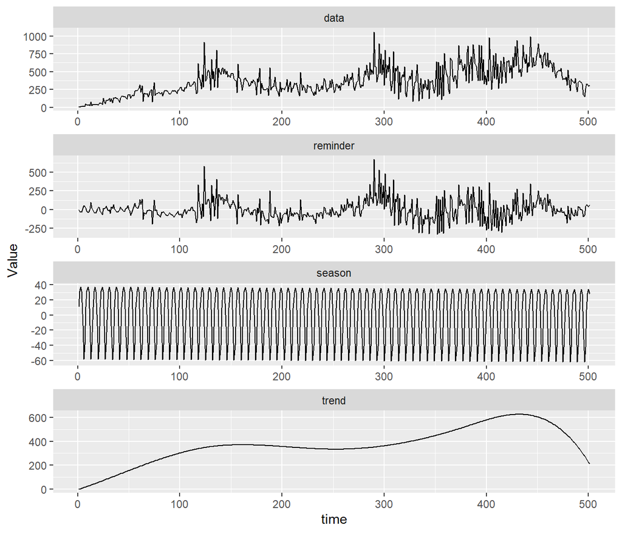

```r
#Decompose the time series:
temp$Trend = Trend
temp$seq = 1 : nrow(temp)
model_decompose2 = lm(Total ~., data = temp[, -1])


trend = coef(model_decompose2)[1] + coef(model_decompose2)['Trend'] * temp$Trend
season = temp$Total - trend - residuals(model_decompose2)


components = cbind(
  time = temp$seq,
  data = temp$Total,
  trend = trend,
  season = season,
  reminder = residuals(model_decompose2))

#graficar
components %>%
  as.data.frame() %>%
  gather(Series, Value, 2 : ncol(.)) %>%
  ggplot(aes(x = time, y = Value)) +
  geom_line() +
  facet_wrap(~Series, scales = 'free', ncol = 1)
```

# 2 Forecast con Regresión Lineal

El enfoque más directo para modelar y proectar series de tiempo es la **regresión lineal**. Podemos escribir una series de tiempos $y_t$ como:

$y_t = \beta_0 + \beta_1 T_t + \sum_{s=1}^S \phi_s S_t +\varepsilon_t$

En donde $S_t$ es el componente estacional que en el caso más sencillo es una variabel **dummy**. Para más detalles sobre regresión y variabels dummy pudes revisar https://rpubs.com/blad0914.

El paquete `forecast` trae consigo la función `tslm` que acepta una formula como objeto y estima los coeficientes de regresión.

```r
covid_total = MA_covid$Total %>%
  ts(frequency = 7)

m_lm = tslm(covid_total ~ trend + season)
summary(m_lm)
```

```
##
## Call:
## tslm(formula = covid_total ~ trend + season)
##
## Residuals:
##     Min      1Q  Median      3Q     Max
## -396.56  -97.50  -20.22   86.43  641.96
##
## Coefficients:
##              Estimate Std. Error t value Pr(>|t|)
## (Intercept) 168.50713   22.04234   7.645  1.1e-13 ***
## trend         0.83243    0.04836  17.215  < 2e-16 ***
## season2      12.10746   26.08863   0.464  0.64279
## season3      40.35534   26.08877   1.547  0.12254
## season4       0.79358   26.08899   0.030  0.97575
## season5      -2.86671   26.18030  -0.109  0.91285
## season6     -80.76582   26.18039  -3.085  0.00215 **
## season7     -39.22611   26.18057  -1.498  0.13470
## ---
## Signif. codes:  0 '***' 0.001 '**' 0.01 '*' 0.05 '.' 0.1 ' ' 1
##
## Residual standard error: 156.5 on 493 degrees of freedom
## Multiple R-squared:  0.3958, Adjusted R-squared:  0.3872
## F-statistic: 46.13 on 7 and 493 DF,  p-value: < 2.2e-16
```

Es importate notar que `trend` y `season` son creados en automático por la función `tslm`. Con el modelo ya calibrado, ahora, podemos hacer un forecast con la función `furecast` para los siguientes 12 dias:

```r
fcs_lm = forecast(m_lm, h = 12)
fcs_lm
```

```
##          Point Forecast    Lo 80    Hi 80    Lo 95    Hi 95
## 72.57143       583.5212 380.6356 786.4067 272.8877 894.1547
## 72.71429       506.4545 303.5689 709.3401 195.8210 817.0880
## 72.85714       548.8266 345.9411 751.7122 238.1931 859.4602
## 73.00000       588.8852 386.0022 791.7681 278.2556 899.5147
## 73.14286       601.8251 398.9421 804.7080 291.1955 912.4546
## 73.28571       630.9054 428.0224 833.7884 320.2758 941.5349
## 73.42857       592.1761 389.2931 795.0590 281.5465 902.8056
## 73.57143       589.3482 386.4287 792.2677 278.6627 900.0337
## 73.71429       512.2815 309.3620 715.2010 201.5960 822.9670
## 73.85714       554.6537 351.7342 757.5732 243.9682 865.3392
## 74.00000       594.7122 391.7948 797.6296 284.0300 905.3944
## 74.14286       607.6521 404.7347 810.5695 296.9699 918.3343
```

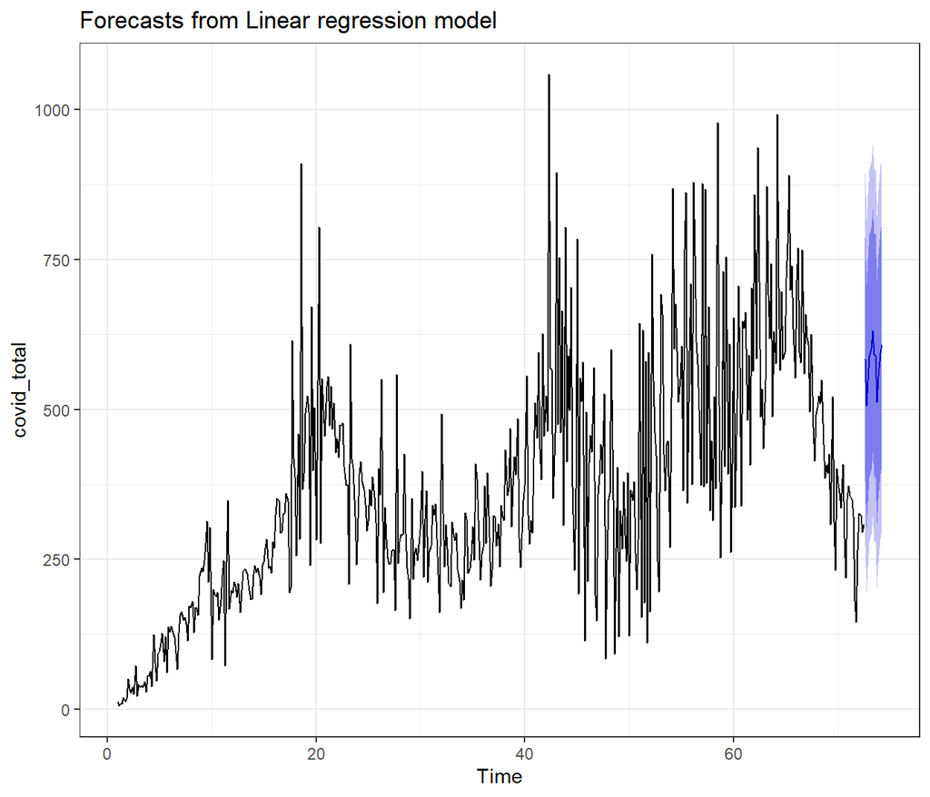

```r
autoplot(fcs_lm) +
  theme_bw()
```

Y también podemos computar los métricos de frecast accuracy con la función `accuracy`:

```r
accuracy(m_lm)
```

```
##                         ME     RMSE      MAE       MPE     MAPE     MASE
## Training set -1.605447e-14 155.2767 118.5523 -48.39371 68.99311 1.064868
##                   ACF1
## Training set 0.3486332
```

Para llevar un registro de los distintos pronósticos que vamos a hacer, vamos a crear un Data Frame de resultados con la fecha, los datos actuales y los estimados:

```r
FCS_Results = MA_covid %>%
  select(Date, Total) %>%
  mutate(m_lm = m_lm$fitted.values)
```

Un aspecto importante del forecast es que hay algunos supuestos que deben cumplir los residuales:

1. los residuales $\varepsilon_t$ deben ser $\text{NID}(0, \sigma^2)$
2. los residuales no deben estar **autocorrelacionados**

Para revisar estos dos spuestos podemos hacer:

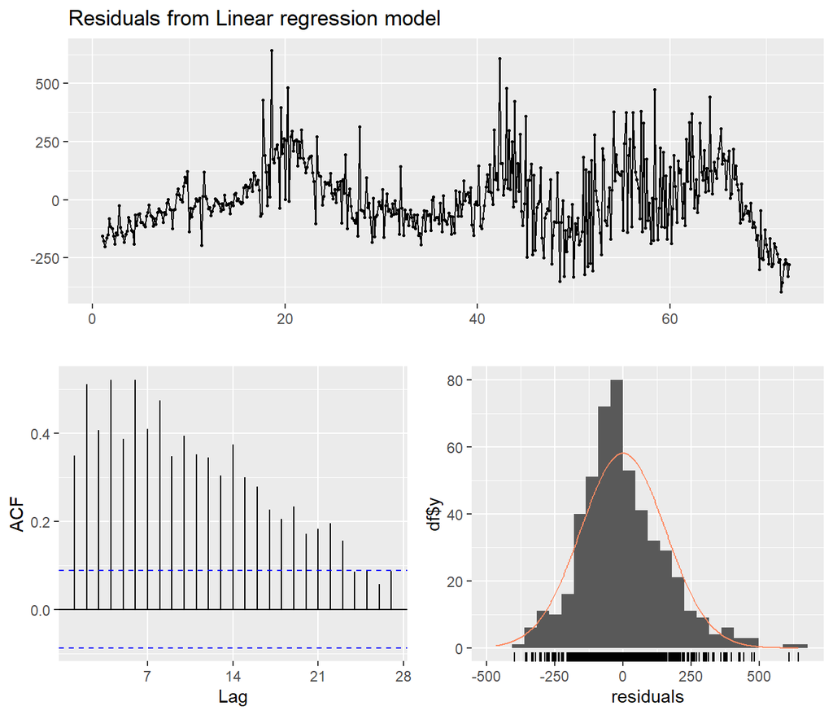

```
##
##  Breusch-Godfrey test for serial correlation of order up to 14
##
## data:  Residuals from Linear regression model
## LM test = 235.41, df = 14, p-value < 2.2e-16
```

```r
checkresiduals(m_lm)
```

Aún cuando la distribución de los residuales parece seguir una forma **gausiana** vemos que en el tiempo no siguen un patrón de ruido blanco y la función de **autocorrelación** o **ACF** muestra que existe autocorrelación significativa.

Este es un problema común cuando queremos modelar series de tiempo con regresión lineal.

# 3 Forecast con Descomposición STL

Una de las ventajas de la descomposición **STL** es que podemos hacer un forecast de una manera relativamente directa:

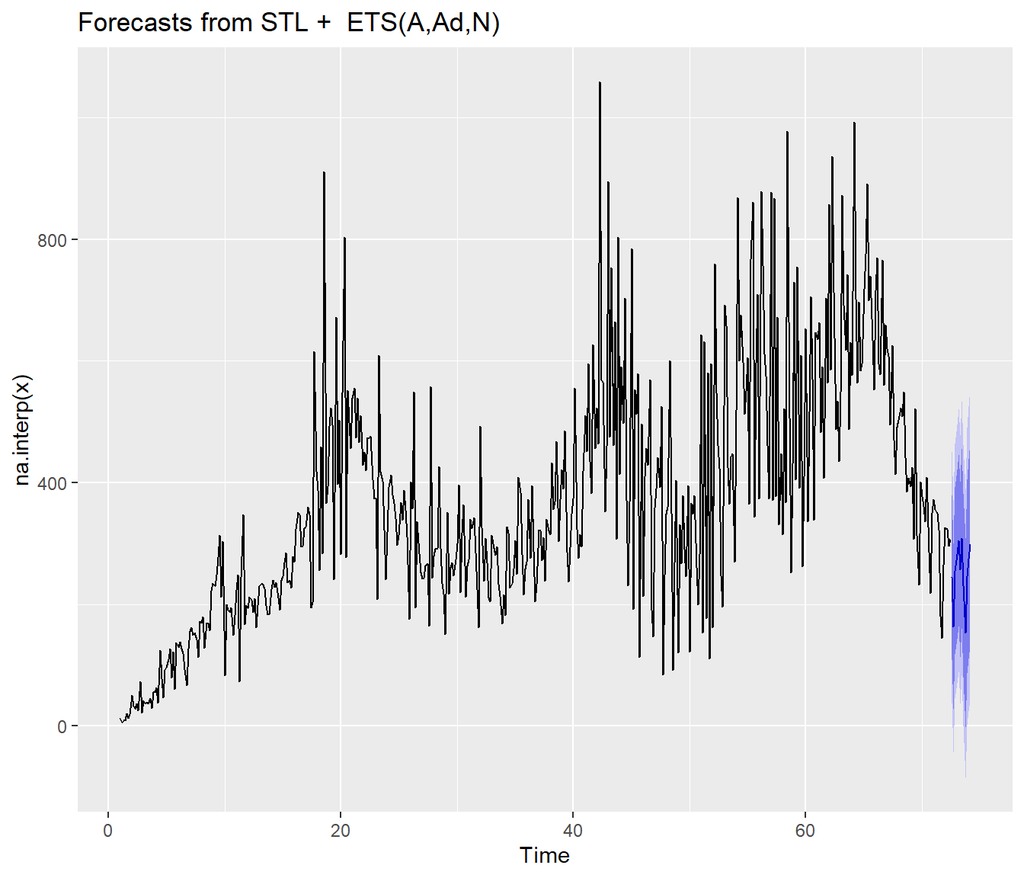

```r
m_stl = MA_covid$Total %>%
  ts(frequency = 7) %>%
  mstl()

#Hacer el forecast
fcs_stl = forecast(m_stl, h = 12)
autoplot(fcs_stl)
```

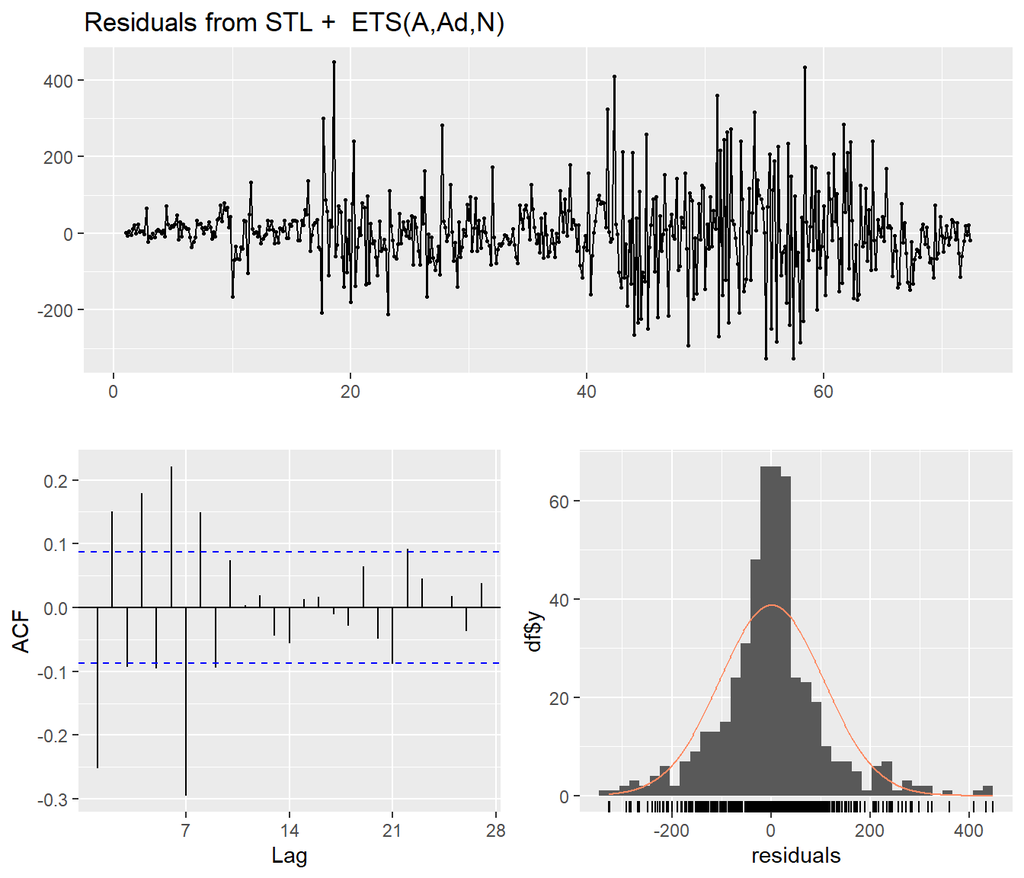

```
##
##  Ljung-Box test
##
## data:  Residuals from STL +  ETS(A,Ad,N)
## Q* = 159.76, df = 9, p-value < 2.2e-16
##
## Model df: 5.   Total lags used: 14
```

```r
#Revisar los residuales
checkresiduals(fcs_stl)
```

```r
#Gardar el valor ajustado
FCS_Results$m_stl = fcs_stl$fitted

#Computar accuracy
accuracy(fcs_stl)
```

```
##                    ME     RMSE     MAE       MPE     MAPE      MASE       ACF1
## Training set 1.395527 104.9593 71.6173 -5.680588 23.14604 0.6432858 -0.2521376
```

# 4 Forecasting con Suavisamiento Exponencial

El **Suavisamiento Exponencial** es una técnica utilizada desde 1957 creada por **Holt**, **Brown** y **Winters**.

## 4.1 Suavisamiento Exponencial Simple (SES)

El caso más sencillo es el **suavisamiento exponencial simple**. Este método es adecuado cuando no hay tendencia y estacionalidad.

El forecast en el tiempo $T+1$ puede escribirse como:

$\hat{y}_{T+1|t} = \alpha y_T + (1-\alpha) \hat{y}_{T|T-1}$

en donde el parámetro de suavisamiento $0 < \alpha < 1$

Si $\ell_{t}$ es el nivel de la serie en el tiempo $t$, entonces podemos escribir el modelo en forma estructural como:

$\text{Forecast: } \hat{y}_{t+h|t} = \ell_{t}$

$\text{Smoothing equation: } \ell_{t} = \alpha y_{t} + (1 - \alpha)\ell_{t-1}$

### 4.1.1 Estimación del modelo

Para estimar el modelo son necesarion métodos de óptimización no lineal con restricciones. Pero en **R** podemos hacerlo con la libreria `forecast` a través de la función `ses`:

```r
m_ses = MA_covid$Total %>%
  ts(frequency = 7) %>%
  ses(h = 12)
summary(m_ses)
```

```
##
## Forecast method: Simple exponential smoothing
##
## Model Information:
## Simple exponential smoothing
##
## Call:
##  ses(y = ., h = 12)
##
##   Smoothing parameters:
##     alpha = 0.1576
##
##   Initial states:
##     l = 19.9024
##
##   sigma:  128.7807
##
##      AIC     AICc      BIC
## 7986.343 7986.391 7998.993
##
## Error measures:
##                    ME     RMSE    MAE      MPE     MAPE     MASE      ACF1
## Training set 3.547519 128.5234 87.918 -9.16764 29.13313 0.789703 -0.169043
##
## Forecasts:
##          Point Forecast    Lo 80    Hi 80    Lo 95    Hi 95
## 72.57143       300.0051 134.9659 465.0442 47.59951 552.4106
## 72.71429       300.0051 132.9289 467.0812 44.48416 555.5259
## 72.85714       300.0051 130.9164 469.0937 41.40634 558.6038
## 73.00000       300.0051 128.9276 471.0825 38.36472 561.6454
## 73.14286       300.0051 126.9617 473.0484 35.35806 564.6520
## 73.28571       300.0051 125.0178 474.9923 32.38518 567.6249
## 73.42857       300.0051 123.0953 476.9148 29.44496 570.5651
## 73.57143       300.0051 121.1935 478.8166 26.53635 573.4738
## 73.71429       300.0051 119.3117 480.6984 23.65835 576.3518
## 73.85714       300.0051 117.4492 482.5609 20.81002 579.2001
## 74.00000       300.0051 115.6056 484.4045 17.99045 582.0196
## 74.14286       300.0051 113.7803 486.2298 15.19880 584.8113
```

En este caso, el problema de optimización tiene que lidear con 2 valores para estimar:

1. El valor del parámetro de suavizamiento, que en este caso es $\alpha = 0.1576$
2. El valor inicial $\ell_0 = 19.90$

### 4.1.2 Forecasting con el modelo SES

Una vez estimado el modelo, podemos hacer el pronóstico:

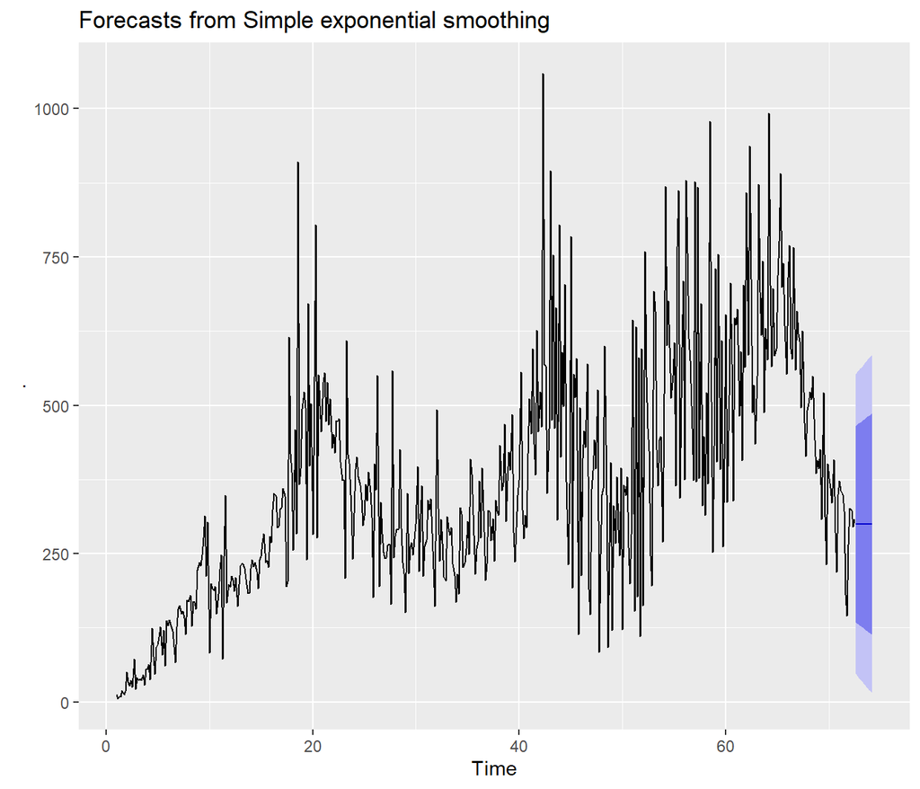

```r
fcs_ses = forecast(m_ses)
autoplot(fcs_ses)
```

Es importante que por definición matemática el valor pronósticado es y será siempre constante.

Ahora podemos registrar el valor estimado y analizar los reidales

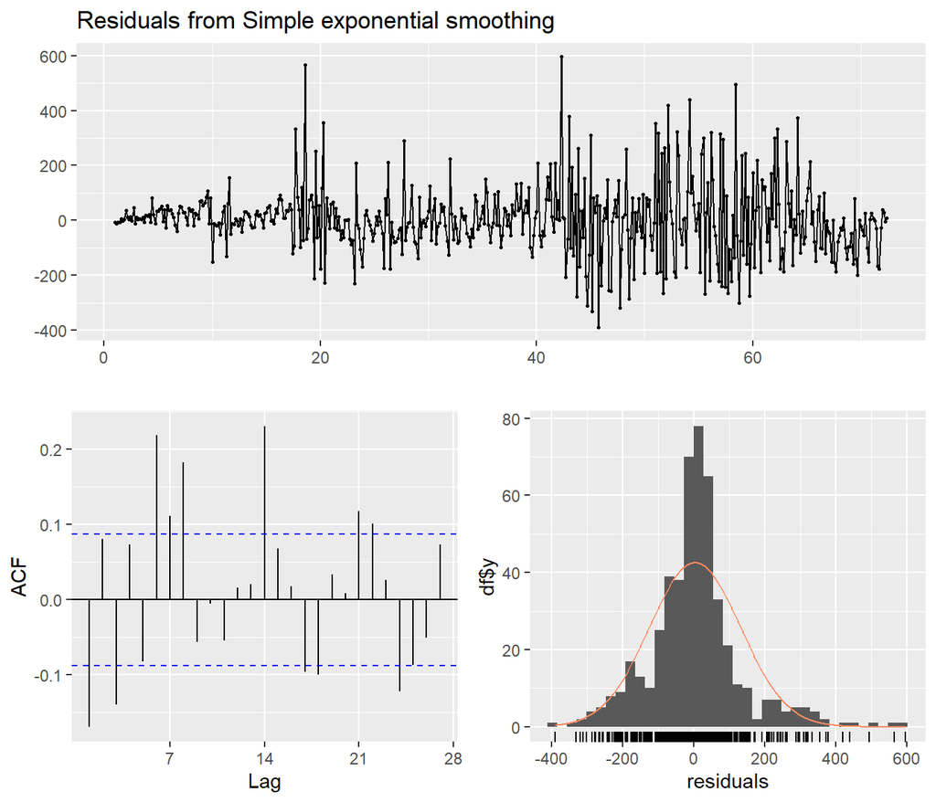

```
##
##  Ljung-Box test
##
## data:  Residuals from Simple exponential smoothing
## Q* = 112.31, df = 12, p-value < 2.2e-16
##
## Model df: 2.   Total lags used: 14
```

```r
FCS_Results$m_ses = fcs_ses$fitted
checkresiduals(m_ses)
```

## 4.2 Suavisamiento de Holt

Podemos ahora incluir el componente de tendencia:

$\text{Forecast equation: } \hat{y}_{t+h|t} = \ell_{t} + hb_{t}$

$\text{Level equation: }\ell_{t} = \alpha y_{t} + (1 - \alpha)(\ell_{t-1} + b_{t-1})$

$\text{Trend equation: }b_{t} = \beta^*(\ell_{t} - \ell_{t-1}) + (1 -\beta^*)b_{t-1}$

Para asegurar **estacionariedad** los valores de $0 < \alpha < 1$ y $0 < \beta < 1$

Igual que el caso anterior, podemos estimar y hacer el forecast para los siguientes 12 dias:

```r
m_holt = MA_covid$Total %>%
  ts(frequency = 7) %>%
  holt(h = 12)
summary(m_holt)
```

```
##
## Forecast method: Holt's method
##
## Model Information:
## Holt's method
##
## Call:
##  holt(y = ., h = 12)
##
##   Smoothing parameters:
##     alpha = 0.1128
##     beta  = 0.0209
##
##   Initial states:
##     l = 5.9318
##     b = 2.077
##
##   sigma:  128.43
##
##      AIC     AICc      BIC
## 7985.598 7985.719 8006.681
##
## Error measures:
##                      ME     RMSE      MAE       MPE     MAPE      MASE
## Training set -0.2999339 127.9163 88.70074 -10.18157 28.69535 0.7967338
##                    ACF1
## Training set -0.1470035
##
## Forecasts:
##          Point Forecast    Lo 80    Hi 80      Lo 95    Hi 95
## 72.57143       260.7702 96.18058 425.3599   9.052086 512.4884
## 72.71429       259.7045 93.65053 425.7585   5.746866 513.6621
## 72.85714       258.6388 90.64643 426.6311   1.716658 515.5609
## 73.00000       257.5730 87.11494 428.0312  -3.120129 518.2662
## 73.14286       256.5073 83.01024 430.0044  -8.833565 521.8482
## 73.28571       255.4416 78.29494 432.5883 -15.480837 526.3640
## 73.42857       254.3759 72.94057 435.8112 -23.105475 531.8572
## 73.57143       253.3102 66.92768 439.6926 -31.737242 538.3575
## 73.71429       252.2444 60.24545 444.2434 -41.392672 545.8815
## 73.85714       251.1787 52.89100 449.4664 -52.076171 554.4336
## 74.00000       250.1130 44.86839 455.3576 -63.781531 564.0075
## 74.14286       249.0473 36.18747 461.9070 -76.493695 574.5882
```

Ahora notemos que existen 4 estimaciones: $\alpha = 0.113$, $\beta = 0.021$ y $\ell_0 = 5.93, b_0 = 2.07$.

El forecast y el análisis de los residuales es:

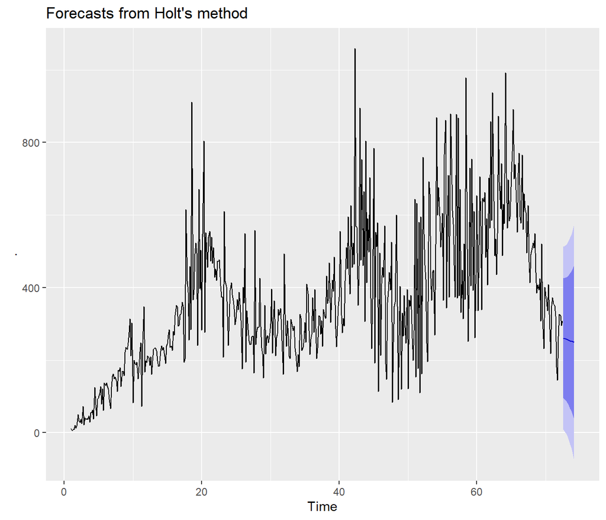

```r
fcs_holt = forecast(m_holt)
FCS_Results$m_holt = fcs_holt$fitted
autoplot(fcs_holt)
```

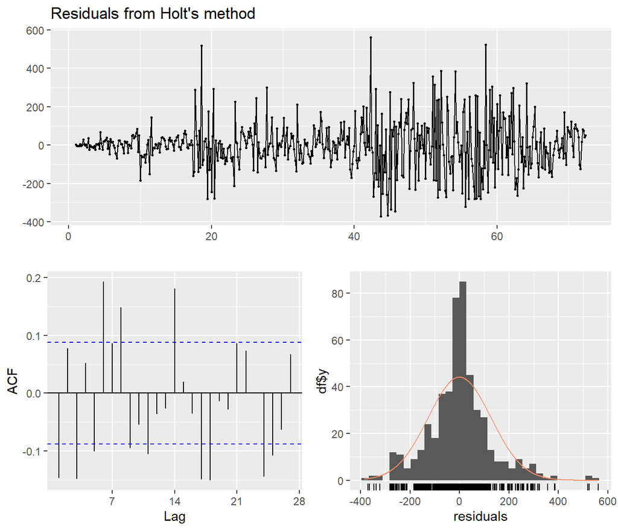

```
##
##  Ljung-Box test
##
## data:  Residuals from Holt's method
## Q* = 95.515, df = 10, p-value = 4.441e-16
##
## Model df: 4.   Total lags used: 14
```

```r
checkresiduals(m_holt)
```

# 5 Suavisamiento Exponencial de Holt-Winters

Ahora vamos a incluir el tercer componente $S_t$:

$\hat{y}_{t+h|t} = \ell_{t} + hb_{t} + s_{t+h-m(k+1)}$

$\ell_{t} = \alpha(y_{t} - s_{t-m}) + (1 - \alpha)(\ell_{t-1} + b_{t-1})$

$b_{t} = \beta^*(\ell_{t} - \ell_{t-1}) + (1 - \beta^*)b_{t-1}$

$s_{t} = \gamma (y_{t}-\ell_{t-1}-b_{t-1}) + (1-\gamma)s_{t-m}$

De la misma forma, los parámetros a estimar del modelo están restringidos para asegurar estacionariedad. Para hacer la estimacón del modelo usamos la función `hw`:

```r
m_hw = MA_covid$Total %>%
  ts(frequency = 7) %>%
  hw(h = 12, seasonal = 'additive')
summary(m_hw)
```

```
##
## Forecast method: Holt-Winters' additive method
##
## Model Information:
## Holt-Winters' additive method
##
## Call:
##  hw(y = ., h = 12, seasonal = "additive")
##
##   Smoothing parameters:
##     alpha = 0.1193
##     beta  = 0.0219
##     gamma = 1e-04
##
##   Initial states:
##     l = -13.9294
##     b = 5.737
##     s = -30.5296 -72.1819 5.2637 11.9236 52.7681 23.0532
##            9.7028
##
##   sigma:  122.7555
##
##      AIC     AICc      BIC
## 7947.212 7947.851 7997.811
##
## Error measures:
##                      ME     RMSE      MAE       MPE     MAPE      MASE
## Training set -0.7316584 121.4004 83.53949 -9.866326 32.18999 0.7503741
##                    ACF1
## Training set -0.2153903
##
## Forecasts:
##          Point Forecast     Lo 80    Hi 80       Lo 95    Hi 95
## 72.57143       261.1095 103.79198 418.4269   20.513137 501.7058
## 72.71429       181.3687  22.49078 340.2467  -61.614130 424.3516
## 72.85714       220.7298  59.79313 381.6665  -25.401615 466.8613
## 73.00000       258.6810  95.13348 422.2286    8.556629 508.8054
## 73.14286       269.7292 102.97335 436.4850   14.698156 524.7602
## 73.28571       297.1412 126.54378 467.7386   36.234957 558.0475
## 73.42857       254.0149  78.91639 429.1135  -13.775183 521.8051
## 73.57143       245.0514  64.77202 425.3309  -30.662142 520.7650
## 73.71429       165.3107 -20.82913 351.4506 -119.365622 449.9871
## 73.85714       204.6718  11.98882 397.3548  -90.011397 499.3550
## 74.00000       242.6230  42.72177 442.5243  -63.099556 548.3456
## 74.14286       253.6712  45.88975 461.4526  -64.103079 571.4454
```

El forecast para los siguientes 12 dias es:

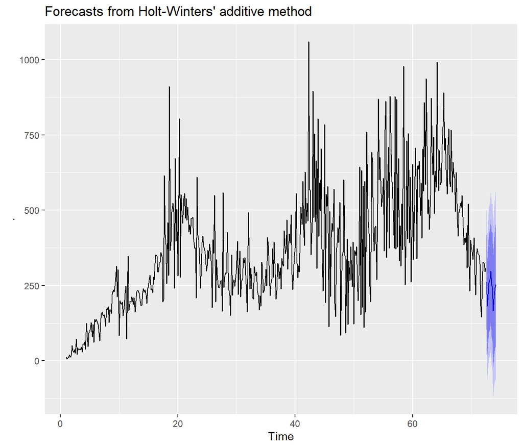

```r
fcs_hw = forecast(m_hw)
autoplot(fcs_hw)
```

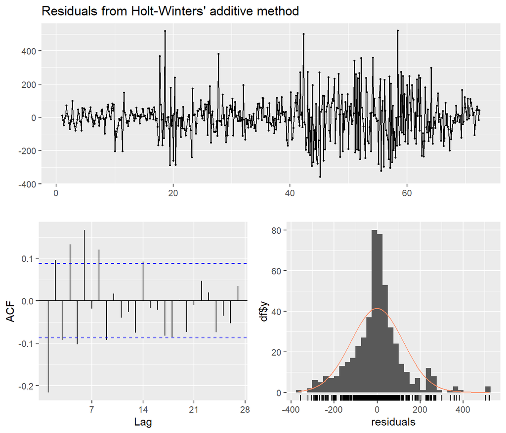

```
##
##  Ljung-Box test
##
## data:  Residuals from Holt-Winters' additive method
## Q* = 81.288, df = 3, p-value < 2.2e-16
##
## Model df: 11.   Total lags used: 14
```

```r
FCS_Results$m_hw = fcs_hw$fitted
checkresiduals(fcs_hw)
```

# 6 Recapitulación de los métodos revisados

Ahora es un bue momento para recapitular y ver cómo los modelos se comportan. Para esto vamos a hacer una gráfica del Actual y los valores ajustados:

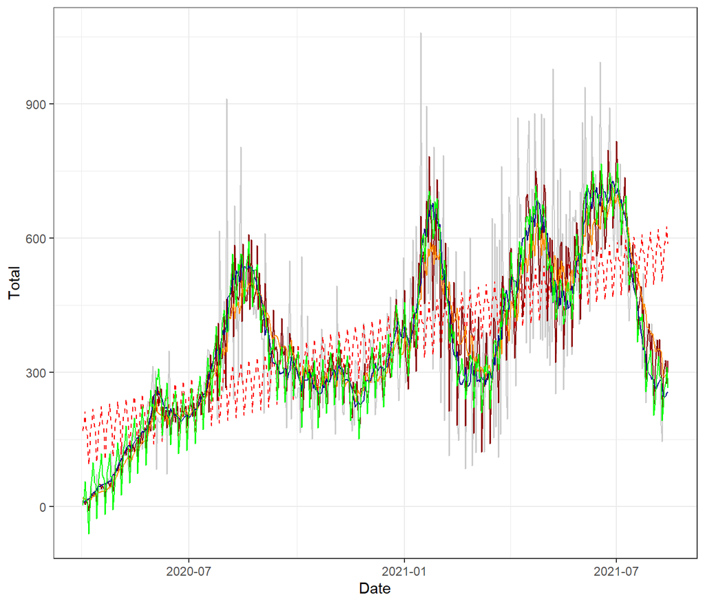

```r
FCS_Results %>%
  ggplot(aes(x = Date, y = Total)) +
  geom_line(color = 'grey80') +
  geom_line(aes(y = m_lm), color = 'red', lty = 2) +
  geom_line(aes(y = m_stl), color = 'darkred') +
  geom_line(aes(y = m_ses), color = 'darkorange') +
  geom_line(aes(y = m_holt), color = 'darkblue') +
  geom_line(aes(y = m_hw), color = 'green') +
  theme_bw()
```

Y ahora vamos a imprimir el accuracy de cada uno de ellos:

```r
fcs_acc = rbind(accuracy(m_lm),
      accuracy(m_ses),
      accuracy(m_holt),
      accuracy(m_hw))

#Convert to Dataframe
fcs_acc = as.data.frame(fcs_acc)
fcs_acc$model = c('lm', 'ses', 'holt', 'hw')
fcs_acc
```

|  | ME | RMSE | MAE | MPE | MAPE | MASE | ACF1 | model |
| --- | --- | --- | --- | --- | --- | --- | --- | --- |
| Training.set | -1.605447e-14 | 155.2767 | 118.55229 | -48.393710 | 68.99311 | 1.0648684 | 0.3486332 | lm |
| Training.set.1 | 3.547519e+00 | 128.5234 | 87.91800 | -9.167640 | 29.13313 | 0.7897030 | -0.1690430 | ses |
| Training.set.2 | -2.999339e-01 | 127.9163 | 88.70074 | -10.181567 | 28.69535 | 0.7967338 | -0.1470035 | holt |
| Training.set.3 | -7.316584e-01 | 121.4004 | 83.53949 | -9.866326 | 32.18999 | 0.7503741 | -0.2153903 | hw |

Cual modelo utilizarías para hacer el pronóstico?

# 7 El engaño de tomar el 100% de los datos

En realidad, para que la competencia sea justa y equilibrada, los modelos deberían competir con datos cigos que nunca han visto.

Ahora vamos a poner a competir el modelo de **holt-winter** con un **MAPE = 32%** contra el modelo de **holt** que tiene un **MAPE = 28%** que en teoría es el que menor error absoluto porcentual tiene. Para esto, vamos a dejar el 95% de los datos para entrenar el modelo y el 5%% para validarlo:

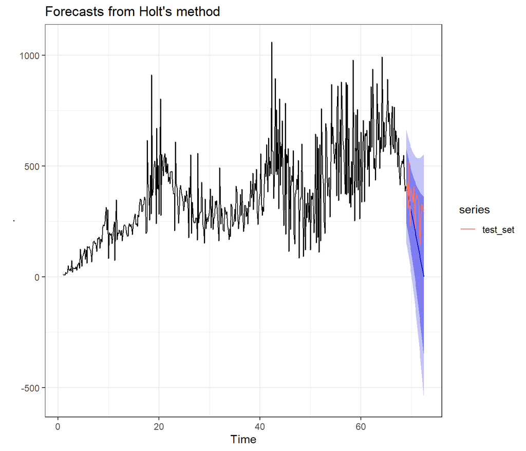

```r
#Crear el training (476 obs) y test set (25 obs)
full_set = ts(MA_covid$Total, frequency = 7)
train_set = subset(full_set, end = length(full_set) - 25)
test_set = subset(full_set, start = length(full_set) - 24)


#Computar los modelos con el training set

#Holt
m_holt = train_set %>%
  holt(h = 25)

m_holt %>%
  forecast(h = 25) %>%
  autoplot() + autolayer(test_set) +
  theme_bw()
```

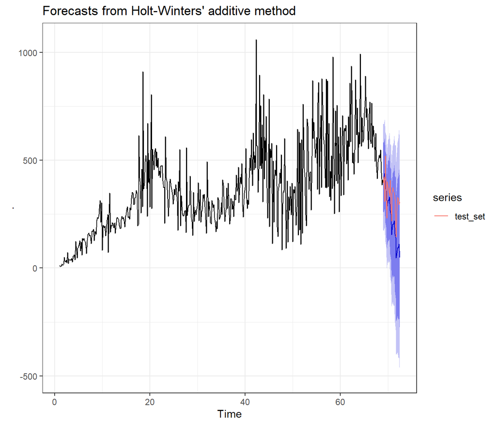

```r
#Holt-Winters
m_hw = train_set %>%
  hw(h = 25)

m_hw %>%
  forecast(h = 25) %>%
  autoplot() + autolayer(test_set) +
  theme_bw()
```

```r
#Accuracy en Test Set para holt
accuracy(m_holt, test = test_set)
```

```
##                     ME     RMSE      MAE       MPE     MAPE     MASE       ACF1
## Training set -27.28181 169.2899 132.0348 -29.33472 47.50481 0.628083 -0.2119841
```

```r
#Accuracy en Test Set para HW
accuracy(m_hw, test = test_set)
```

```
##                     ME     RMSE      MAE       MPE     MAPE      MASE
## Training set -1.329279 140.5487 104.1309 -15.76532 34.34836 0.4953457
##                    ACF1
## Training set -0.2432873
```

Ahora lo que observamos es que el Holt-Winter con un 34% en el test set supera al modelo de Holt el cual tiene un 47% de error.

# 8 Bibliografia

https://otexts.com/fpp2/